# Final Project: Absolutism in Denmark and Sweden

Asta Hoegh Gregersen

2026-05-16

```r
knitr::opts_chunk$set(echo = TRUE)
```

# Thoughts before starting the analysis

As has been outlined in the written part of this assignment, I believe that absolutism greatly benefited the monarchs of Denmark and Sweden, and led to longer reigns on average. Absolutism clearly defined the power of the monarchs, and put a stop to struggles over the throne. This meant that monarchs lived longer, and were thus able to reign longer. The effects of a long-lasting monarch and few battles over succession, lead to stability within the nation for a time. Some in society probably criticized the monarchy and its absolute powers, but I argue that absolutism did benefit society in many ways. Absolutism was in effect in Denmark for almost 200 years, so it is supremely relevant to focus on the Danish monarchy when exploring the effects of absolutism.  
Absolutism in Sweden is very interesting. Unlike many European nations, absolutism in Sweden only lasted for 47 years. Despite this, the reigns of the two Swedish absolutist monarchs were considerably longer than the average duration of reign for a Swedish monarch before absolutism. The unique circumstances under which absolutism was introduced in Sweden will be explored further in the written part of the assignment. As has been outlined, I strongly suspect that the average duration of reign for the monarchs who ruled during absolutism in both nations will be higher than the average for all monarchs, and significantly higher than the average for the monarchs that ruled before absolutism.

## Loading relevant packages

```r
library(tidyverse)
library(here)
```

## Creating relevant folders

```r
dir.create("data")
```

```r
dir.create("figures")
```

## Creating dataframes from the datasets

```r
danish_monarchs <-read.csv2("data/danish_monarchs_dataset_2026.CSV")
danish_monarchs
```

```
##                     regent gender birth death first_year_ruled last_year_ruled
## 1              Frederik_10   male  1968  <NA>             2024              NA
## 2              Margrethe_2 female  1940   NA              1972            2024
## 3               Frederik_9   male  1899  1972             1947            1972
## 4             Christian_10   male  1870  1947             1912            1947
## 5               Frederik_8   male  1843  1912             1906            1912
## 6              Christian_9   male  1818  1906             1863            1906
## 7              Frederik_7    male  1808  1863             1848            1863
## 8              Christian_8   male  1786  1848             1839            1848
## 9               Frederik_6   male  1768  1839             1808            1839
## 10             Christian_7   male  1749  1808             1766            1808
## 11              Frederik_5   male  1723  1766             1746            1766
## 12             Christian_6   male  1699  1746             1730            1746
## 13              Frederik_4   male  1671  1730             1699            1730
## 14            Christian_5    male  1646  1699             1670            1699
```

[output cut: 42 more lines]

```r
swedish_monarchs <-read.csv2("data/swedish_monarchs_dataset_2026.CSV")
swedish_monarchs
```

```
##                        regent  gender birth death first_year_ruled
## 1              Carl_16_Gustaf   male   1946    NA             1973
## 2             Gustraf_6_Adolf   male   1882  1973             1950
## 3                    Gustaf_5   male   1858  1950             1907
## 4                     Oskar_2   male   1829  1907             1872
## 5                     Karl_15   male   1826  1872             1859
## 6                     Oskar_1   male   1799  1859             1844
## 7               Karl_14_Johan   male   1763  1844             1818
## 8                     Karl_13   male   1749  1818             1809
## 9              Gustav_4_Adolf   male   1778  1837             1792
## 10                   Gustav_3   male   1746  1792             1771
## 11             Adolf_Frederik   male   1710  1771             1751
## 12                 Frederik_1   male   1676  1751             1720
## 13  Ulrika_Eleonora_den_yngre female   1688  1741             1719
## 14                    Karl_12   male   1682  1718             1697
```

[output cut: 151 more lines]

## Creating vectors of the columns of the Danish monarchs

```r
regent_denmark<-danish_monarchs[[1]]
gender_denmark<-danish_monarchs[[2]]
birth_denmark<-danish_monarchs[[3]]
death_denmark<-danish_monarchs[[4]]
first_year_ruled_denmark<-danish_monarchs[[5]]
last_year_ruled_denmark<-danish_monarchs[[6]]
```

## Creating vectors of the columns of the Swedish monarchs

```r
regent_sweden<-swedish_monarchs[[1]]
gender_sweden<-swedish_monarchs[[2]]
birth_sweden<-swedish_monarchs[[3]]
death_sweden<-swedish_monarchs[[4]]
first_year_ruled_sweden<-swedish_monarchs[[5]]
last_year_ruled_sweden<-swedish_monarchs[[6]]
```

## Creating a new column in each dataset

This assignment has a focus on duration of reign in relation to absolutism. To examine this, a column containing the number of years each monarch reigned is required. Within both dataframes, a new column is created, containing the number of years each monarch ruled. The columns are going to be called no_years_ruled in each dataframe. A vector is then created of each of these columns, and the work with the data can begin.

```r
danish_monarchs<-danish_monarchs%>%mutate(no_years_ruled=last_year_ruled-as.numeric(first_year_ruled))
no_years_ruled_denmark<-danish_monarchs[[7]]

no_years_ruled_denmark
```

```
##  [1] NA 52 25 35  6 43 15  9 31 42 20 16 31 29 22 52 29 23 10 10 31 33  8 43  9
## [26] 12 35  3  3  7 33 27  7  2  9 39 20 25 11 11 11  9  3 30  8  9  6  6 27  5
## [51]  7 17  4 NA NA NA
```

```r
swedish_monarchs<-swedish_monarchs%>%mutate(no_years_ruled=last_year_ruled-as.numeric(first_year_ruled))

no_years_ruled_sweden<-swedish_monarchs[[7]]

no_years_ruled_sweden
```

```
##  [1] NA 23 43 35 13 15 26  9 17 21 20 31  1 21 37  6 22 21  7  7 24  8 37  3  8
## [26]  0  7  2  4 27  3  1  1  0  1  0  7  0  0  9  0  0  8  2  1  3 39 23 26  2
## [51]  3 45  1 28 15 25 18 16  5  7  6  8 12 29  6  6  6  1 10 26 NA NA  2 26  9
## [76]  5  3  6 10 28 27 25
```

# Working with the data

The hypothesis at the center of this project, is that monarchs, whether Danish or Swedish, on average reigned longer during absolutism. The average duration of reign overall, before and during absolutism will be found. Then, the different averages will be compared.

# Average duration of reign in Denmark in relation to absolutism

The column ‘no_years_ruled’ has been made into a vector, and then the average duration of reign across all monarchs can be found, using the mean() function.

```r
mean(no_years_ruled_denmark,na.rm=TRUE)
```

```
## [1] 19.42308
```

Thus, the overall average duration of reigns for the Danish monarchs are 19,4 years.

## Creating a dataframe containing only the Danish monarchs that reigned during absolutism

Now, two new data frames will be created. The first will contain the monarchs who ruled during absolutism. The second will contain the monarchs who ruled before absolutism. This will firstly be done with the Danish monarchs, and then with the Swedish monarchs in the next part of the assignment.

After having conducted research about the Danish monarchs that reigned during absolutism, I know that the monarch who introduced absolutism was Frederik the 3rd, whose reign began in 1648. The last king to rule during absolutism was Christian the 8th. His death in 1848 marked the end of absolutism in Denmark.

The filter() function is used to create the new data frame. Using first_year_ruled_denmark>1647, any monarch who reigned before 1647 is excluded, as Frederik the 3rd ascended the throne in 1648. Using last_year_ruled_denmark<1849, any monarchs who ruled after 1849 are excluded and Christian the 8th is included, as the last year of his reign was 1848

no_years_ruled_denmark!= “NA” ensures that any monarchs whose reign does not have either a start or an end, due to insufficient historical knowledge, are not included in the dataframe.

```r
danish_monarchs_during_absolutism <- filter(danish_monarchs,first_year_ruled_denmark>1647,
       last_year_ruled_denmark<1849, no_years_ruled_denmark!="NA")
danish_monarchs_during_absolutism
```

```
##         regent gender birth death first_year_ruled last_year_ruled
## 1  Christian_8   male  1786  1848             1839            1848
## 2   Frederik_6   male  1768  1839             1808            1839
## 3  Christian_7   male  1749  1808             1766            1808
## 4   Frederik_5   male  1723  1766             1746            1766
## 5  Christian_6   male  1699  1746             1730            1746
## 6   Frederik_4   male  1671  1730             1699            1730
## 7 Christian_5    male  1646  1699             1670            1699
## 8   Frederik_3   male  1609  1670             1648            1670
##   no_years_ruled
## 1              9
## 2             31
## 3             42
## 4             20
## 5             16
## 6             31
## 7             29
## 8             22
```

Now that a new dataframe has been created, one can make a vector of the column no_years_ruled, and then use the mean() function to find the average duration of reign for the 8 monarchs that reigned during absolutism.

```r
no_years_ruled_during_absolutism_denmark <- danish_monarchs_during_absolutism[[7]]

no_years_ruled_during_absolutism_denmark
```

```
## [1]  9 31 42 20 16 31 29 22
```

```r
mean(no_years_ruled_during_absolutism_denmark,na.rm=TRUE)
```

```
## [1] 25
```

Thus, the average duration of reign during absolutism was 25, which is 5,6 years higher than the average duration of reign for all the Danish monarchs.

Now, a third data frame will be created, which contains only the monarchs that reigned before absolutism. Then one is able to compare the overall average duration of reign, the average duration of reign during absolutism and the average duration of reign before absolutism.

## Creating a dataframe containing only the Danish monarchs that reigned before absolutism

The same functions as was used to create the previous data frame, is employed. first_year_ruled_denmark<1647 ensured that only the kings who reigned before Frederik the 3rd ascended the throne in 1648, are included.

```r
danish_monarchs_before_absolutism <- filter(danish_monarchs,first_year_ruled_denmark<1647, no_years_ruled_denmark!="NA")

danish_monarchs_before_absolutism
```

```
##                     regent gender birth death first_year_ruled last_year_ruled
## 1              Christian_4   male  1577  1648             1596            1648
## 2               Frederik_2   male  1534  1588             1559            1588
## 3             Christian_3    male  1503  1559             1536            1559
## 4               Frederik_1   male  1471  1533             1523            1533
## 5              Christian_2   male  1481  1559             1513            1523
## 6                    Hans    male  1455  1513             1482            1513
## 7              Christian_1   male  1426  1481             1448            1481
## 8  Christoffer_3_af_Bayern   male  1416  1448             1440            1448
## 9        Erik_7_af_Pommern   male  1382  1459             1396            1439
## 10             Margrethe_1 female  1353  1412             1387            1396
## 11                  Oluf_2   male  1370  1387             1375            1387
## 12     Valdemar_4_Atterdag   male  1320  1375             1340            1375
## 13           Christoffer_2   male  1276  1332             1329            1332
## 14              Valdemar_3   male  1315  1364             1326            1329
```

[output cut: 63 more lines]

Then, the column containing the number of years reigned can be made into a vector, and the mean() function can be used to find the average duration of reign for the Danish monarchs before absolutism.

```r
no_years_ruled_before_absolutism_denmark <- danish_monarchs_before_absolutism[[7]]

no_years_ruled_before_absolutism_denmark
```

```
##  [1] 52 29 23 10 10 31 33  8 43  9 12 35  3  3  7 33 27  7  2  9 39 20 25 11 11
## [26] 11  9  3 30  8  9  6  6 27  5  7 17  4
```

```r
mean(no_years_ruled_before_absolutism_denmark,na.rm=TRUE)
```

```
## [1] 16.68421
```

The average duration of reign before absolutism was 16,7 years. This is 2,7 years shorter than the overall average, and 8,3 years shorter than the average duration of reign during absolutism. Thus, the monarchs that ruled during absolutism did indeed ruled longer on average than the monarchs who ruled before absolutism. They also ruled longer than the overall average across all Danish monarchs through time.

# Average duration of reign in Sweden in relation to absolutism

In order to compare absolutism in Denmark and Sweden, the same calculations must be performed.

```r
mean(no_years_ruled_sweden,na.rm=TRUE)
```

```
## [1] 13.10127
```

## Creating a dataframe containing only the Swedish monarchs that reigned during absolutism

Now, as has been done previously, two new data frames will be created. The first will contain the monarchs who ruled during absolutism in Sweden. The second will contain the Swedish monarchs who ruled before absolutism.

After having conducted research about absolutism in Sweden, I know that absolutism oficially began in 1672, when Karl the 11th became of legal age, and ended in 1719, after Karl the 12th death in 1718

```r
swedish_monarchs_during_absolutism <- filter(swedish_monarchs,first_year_ruled_sweden>1659,
       last_year_ruled_sweden<1720, no_years_ruled_sweden!="NA",birth!="NA")

swedish_monarchs_during_absolutism
```

```
##    regent gender birth death first_year_ruled last_year_ruled no_years_ruled
## 1 Karl_12  male   1682  1718             1697            1718             21
## 2 Karl_11  male   1655  1697             1660            1697             37
```

```r
no_years_ruled_during_absolutism_sweden <- swedish_monarchs_during_absolutism[[7]]

no_years_ruled_during_absolutism_sweden
```

```
## [1] 21 37
```

```r
mean(no_years_ruled_during_absolutism_sweden,na.rm=TRUE)
```

```
## [1] 29
```

Thus, the average duration of reign during absolutism in Sweden was 29, which is 15,9 years higher than the average duration of reign for all the Swedish monarchs.

Now, a third data frame will be created, which contains only the monarchs that reigned before absolutism. Then the same results have been found across both nations, and then one can begin to compare and contrast absolutism in Denmark and Sweden.

## Creating a dataframe containing only the Swedish monarchs that reigned before absolutism

The same functions as was used to create the previous data frame, is employed. first_year_ruled_sweden<1659 ensures that only the monarchs who reigned before Karl the 11th are included.

```r
swedish_monarchs_before_absolutism <- filter(swedish_monarchs,first_year_ruled_sweden<1659, no_years_ruled_sweden!="NA")

swedish_monarchs_before_absolutism
```

```
##                        regent  gender birth death first_year_ruled
## 1              Karl_10_Gustav   male   1622  1660             1654
## 2                   Kristina  female   1626  1689             1632
## 3              Gustav_2_Adolf   male   1594  1632             1611
## 4                      Karl_9   male   1550  1611             1604
## 5                  Sigismund    male   1566  1632             1592
## 6                     Johan_3   male   1537  1592             1568
## 7                     Erik_14   male   1533  1577             1560
## 8                Gustav_Vasa    male   1496  1560             1523
## 9                 Christian_2   male   1481  1559             1520
## 10       Sten_Sture_den_yngre   male     NA  1520             1512
## 11                Erik_Trolle   male   1460    NA             1512
## 12             Svante_Nilsson   male   1460  1511             1504
## 13      Sten_Sture_den_aaldre   male   1440  1503             1501
## 14                       Hans   male   1455  1513             1497
```

[output cut: 115 more lines]

Then, the column containing the number of years reigned can be made into a vector, and the mean() function can be used to find the average duration of reign for the Swedish monarchs before absolutism.

```r
no_years_ruled_before_absolutism_sweden <- swedish_monarchs_before_absolutism[[7]]

no_years_ruled_before_absolutism_sweden
```

```
##  [1]  6 22 21  7  7 24  8 37  3  8  0  7  2  4 27  3  1  1  0  1  0  7  0  0  9
## [26]  0  0  8  2  1  3 39 23 26  2  3 45  1 28 15 25 18 16  5  7  6  8 12 29  6
## [51]  6  6 10 26  2 26  9  5  3  6 10 28 27 25
```

```r
mean(no_years_ruled_before_absolutism_sweden,na.rm=TRUE)
```

```
## [1] 11.28125
```

## Comparing the results

# Plotting the results

To support my hypothesis, and to properly showcase the effect of absolutism in the two nations, different plots will be created. Firstly, plots showcasing data relating Danish absolutism, and then plots showcasing data relating to Swedish absolutism.

# Visualizing the findings relating to absolutism in Denmark

## Duration of reign during absolutism, Denmark - duration over time

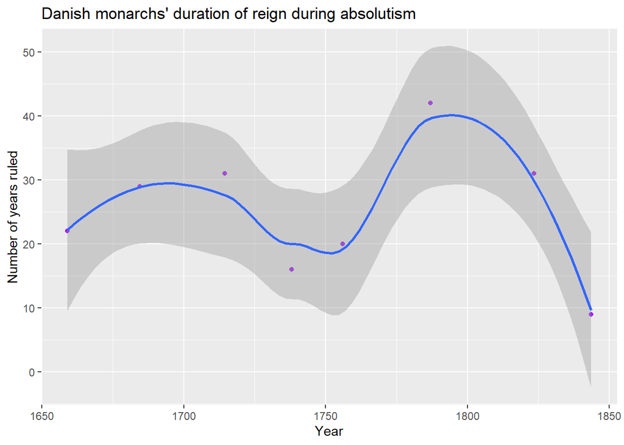

```r
denmark_absolutism_dot <- danish_monarchs_during_absolutism %>% mutate(no_years_ruled) %>%
  mutate(mid_year=(as.numeric(first_year_ruled)+(no_years_ruled)/2))%>%
  ggplot(aes(x=mid_year,y=no_years_ruled))+
  geom_point(color="purple")+
               geom_smooth()+
  labs(title="Danish monarchs' duration of reign during absolutism")+
  labs(y="Number of years ruled", x="Year")

# Showing the plot
denmark_absolutism_dot
```

```r
# Saving as a png
ggsave(plot = denmark_absolutism_dot,
       here("figures","denmark_absolutism_dot.png"),
       height = 6,
       width = 8)
```

## Duration of reign before absolutism, Denmark - duration over time

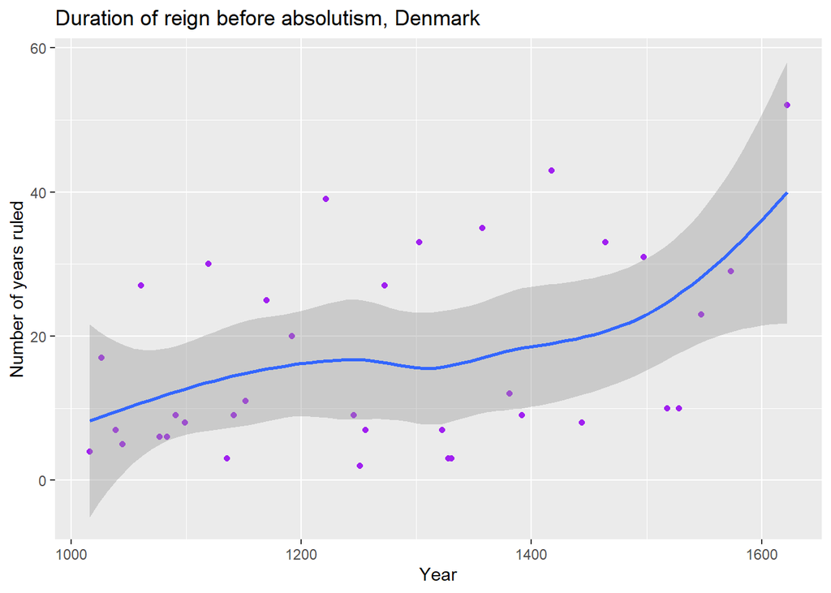

```r
denmark_before_absolutism_dot <- danish_monarchs_before_absolutism %>% mutate(no_years_ruled) %>%
  mutate(mid_year=(as.numeric(first_year_ruled)+(no_years_ruled)/2))%>%
  ggplot(aes(x=mid_year,y=no_years_ruled))+
  geom_point(color="purple")+
               geom_smooth()+
  labs(title="Duration of reign before absolutism, Denmark")+
  labs(x="Year",y="Number of years ruled")

# Showing the plot
denmark_before_absolutism_dot
```

```r
# Saving as a png
ggsave(plot = denmark_before_absolutism_dot,
       here("figures","denmark_before_absolutism_dot.png"),
       height = 6,
       width = 8)
```

## Average duration of reign before absolutism, Denmark - barplot

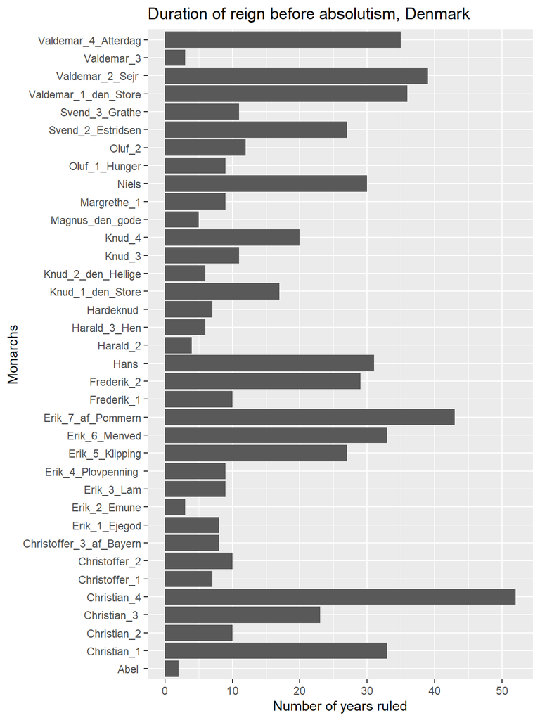

```r
denmark_before_absolutism_barplot <-ggplot(danish_monarchs_before_absolutism, aes(x=regent,y=no_years_ruled))+geom_bar(stat="identity") + coord_flip()+
  labs(title="Duration of reign before absolutism, Denmark")+
  labs(x="Monarchs",y="Number of years ruled")

# Showing the plot
denmark_before_absolutism_barplot
```

```r
# Saving the plot as a png
ggsave(plot = denmark_before_absolutism_barplot,
       here("figures","denmark_before_absolutism_barplot.png"),
       height = 8,
       width = 6)
```

## Average duration of reign during absolutism, Denmark - barplot

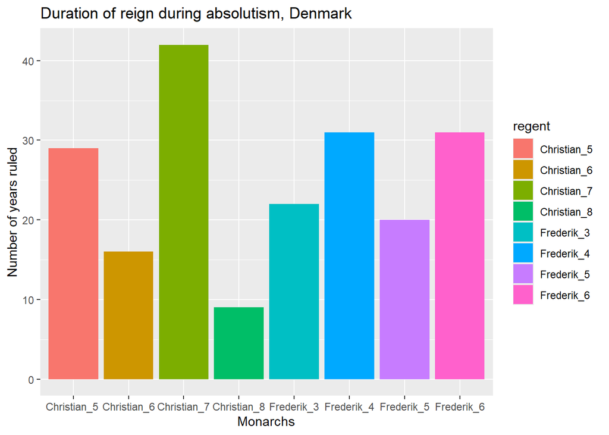

```r
denmark_absolutism_barplot <- ggplot(danish_monarchs_during_absolutism, aes(x=regent,y=no_years_ruled))+geom_col(aes(fill=regent))+
  labs(title="Duration of reign during absolutism, Denmark")+
  labs(x="Monarchs",y="Number of years ruled")

# Showing the plot
denmark_absolutism_barplot
```

```r
# Saving as a png
ggsave(plot = denmark_absolutism_barplot,
       here("figures","denmark_absolutism_barplot.png"),
       height = 6,
       width = 8)
```

# Visualizing the findings relating to absolutism in Sweden

## Average duration of reign in Sweden before absolutism - duration over time

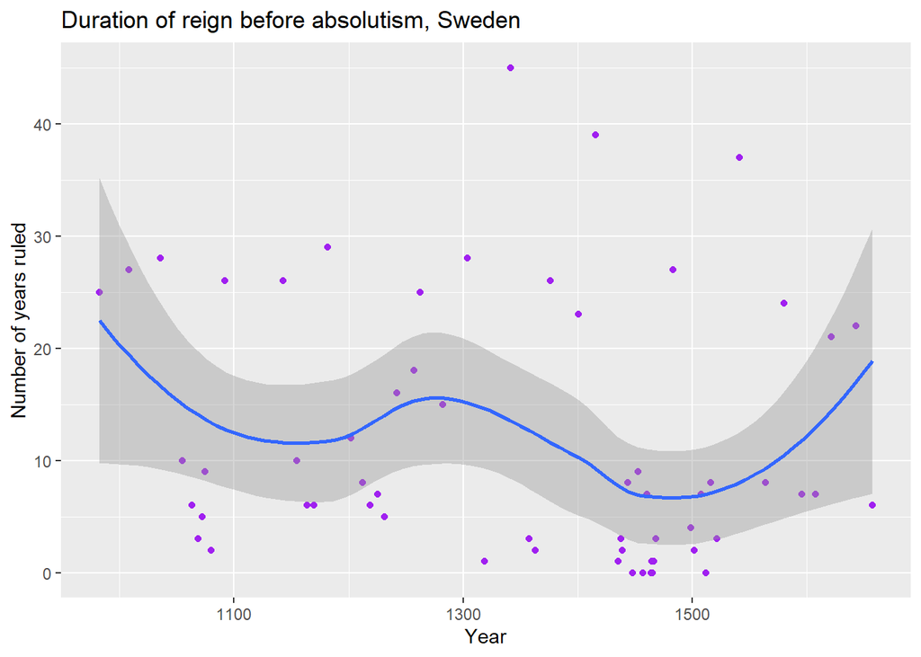

```r
sweden_before_absolutism_dot <- swedish_monarchs_before_absolutism %>% mutate(no_years_ruled) %>%
  mutate(mid_year=(as.numeric(first_year_ruled)+(no_years_ruled)/2))%>%
  ggplot(aes(x=mid_year,y=no_years_ruled))+
  geom_point(color="purple")+
               geom_smooth()+
  labs(title="Duration of reign before absolutism, Sweden")+
  labs(x="Year",y="Number of years ruled")

# Showing the plot
sweden_before_absolutism_dot
```

```r
# Saving as a png
ggsave(plot = sweden_before_absolutism_dot,
       here("figures","sweden_before_absolutism_dot.png"),
       height = 6,
       width = 8)
```

## Duration of reign in Sweden before absolutism - barplot

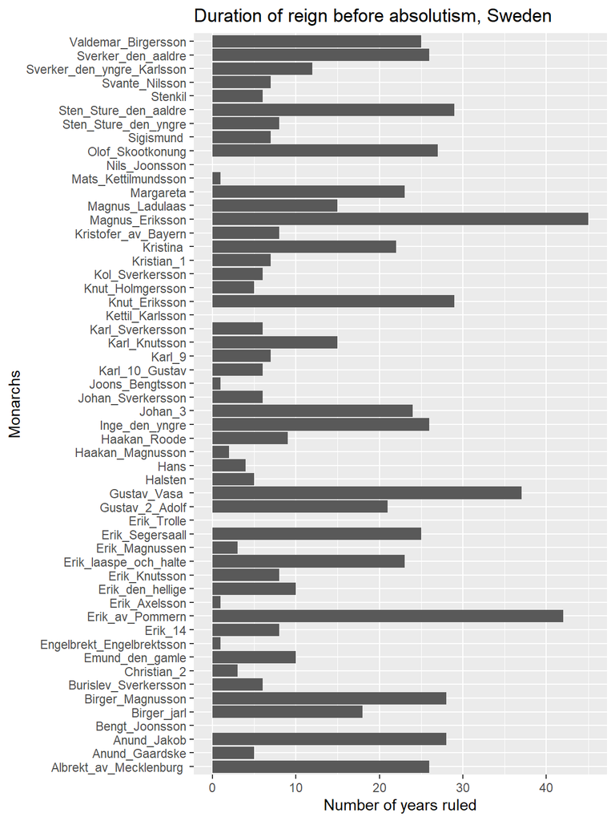

```r
sweden_before_absolutism_barplot <- ggplot(swedish_monarchs_before_absolutism, aes(x=regent,y=no_years_ruled))+geom_bar(stat="identity")+ coord_flip()+labs(title="Duration of reign before absolutism, Sweden")+
  labs(x="Monarchs",y="Number of years ruled")

# Showing the plot
sweden_before_absolutism_barplot
```

```r
# Saving as a png
ggsave(plot = sweden_before_absolutism_barplot,
       here("figures","sweden_before_absolutism_barplot.png"),
       height = 8,
       width = 6)
```

## Duration of reign in Sweden during absolutism - barplot

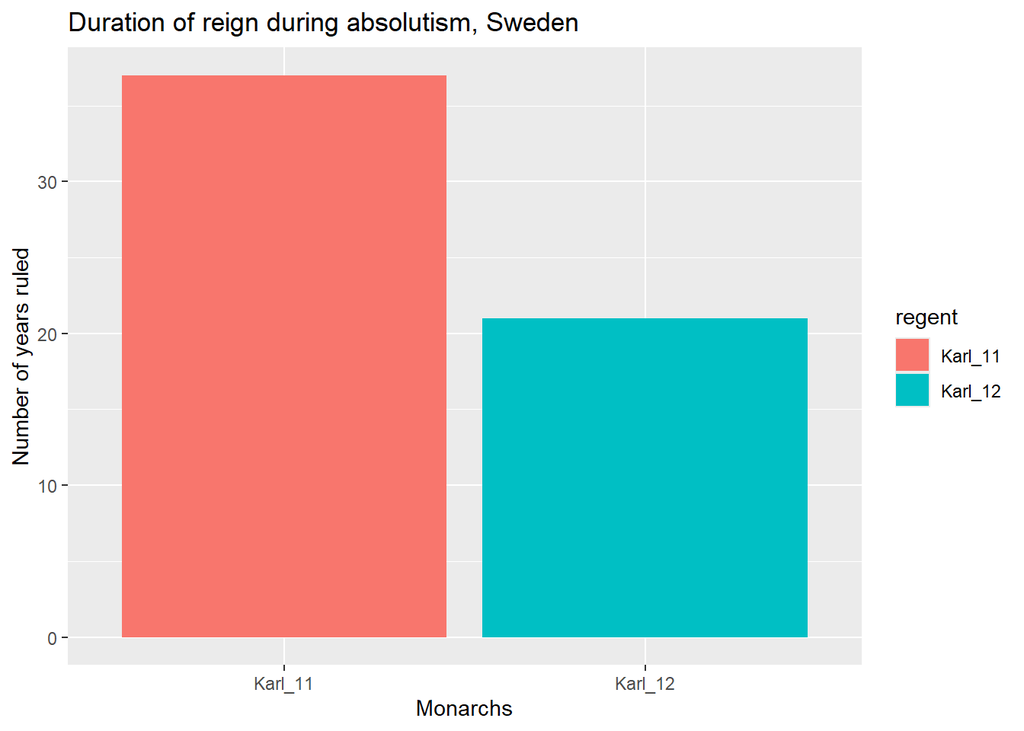

```r
sweden_absolutism_barplot <- ggplot(swedish_monarchs_during_absolutism, aes(x=regent,y=no_years_ruled))+geom_col(aes(fill=regent))+labs(title="Duration of reign during absolutism, Sweden")+
  labs(x="Monarchs",y="Number of years ruled")

# Showing the plot
sweden_absolutism_barplot
```

```r
# Saving as a png
ggsave(plot = sweden_absolutism_barplot,
       here("figures","sweden_absolutism_barplot.png"),
       height = 6,
       width = 8)
```

# Conclusion